# notes > dc > correlation and regression with Ben

scatterplots

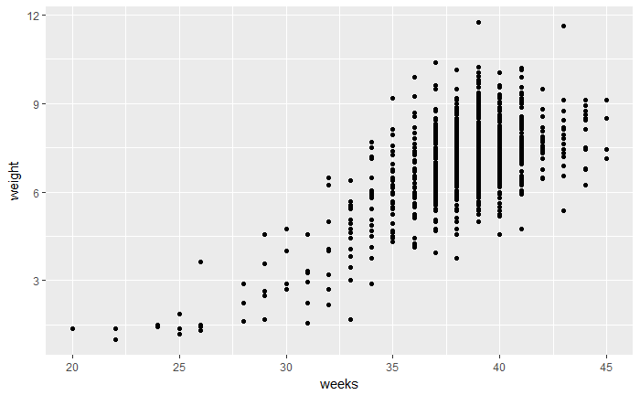

boxplots as discretized/conditioned scatterplots

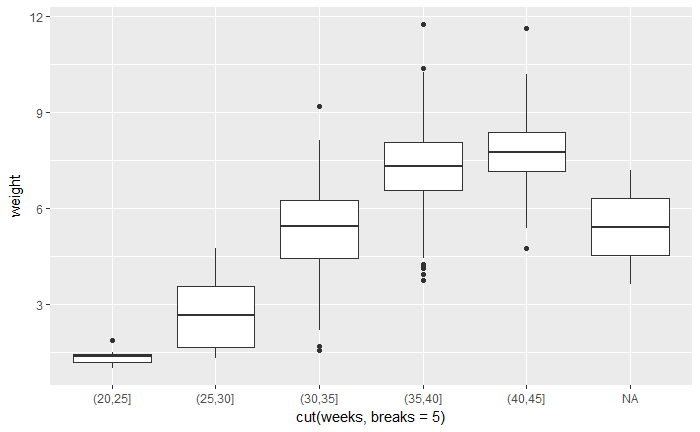

```r
# Boxplot of weight vs. weeks
ggplot(data = ncbirths,
       aes(x = cut(weeks, breaks = 5), y = weight)) +
  geom_boxplot()
```

Characterizing bivariate relationships

- form (linear, quadratic, non-linear)
- direction
- strength (how much scatter/noise)
- outliers

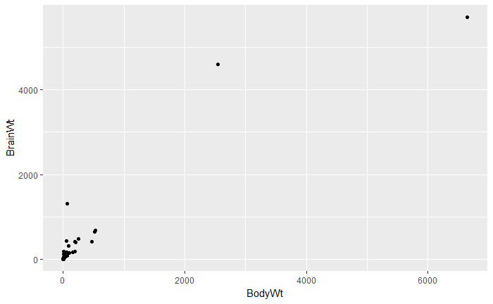

```r
# Mammals scatterplot
ggplot(data = mammals,
  aes(x = BodyWt, y = BrainWt)) +
  geom_point()
```

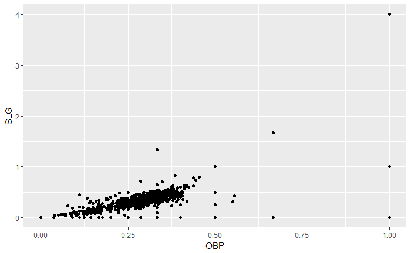

```r
# Baseball player scatterplot
ggplot(data = mlbBat10,
  aes(x = OBP, y = SLG )) +
  geom_point()
```

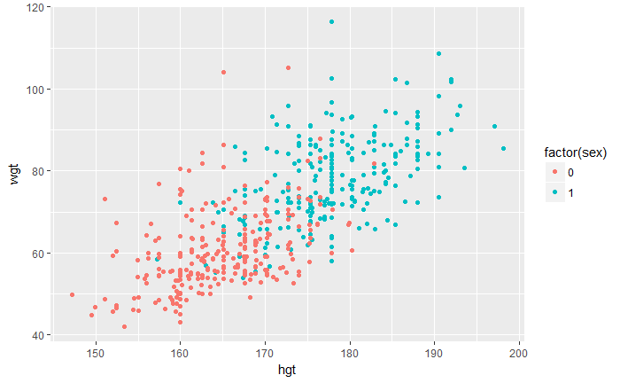

```r
# Body dimensions scatterplot
ggplot(data = bdims,
  aes(x = hgt, y = wgt, color = factor(sex))) +
  geom_point()
```

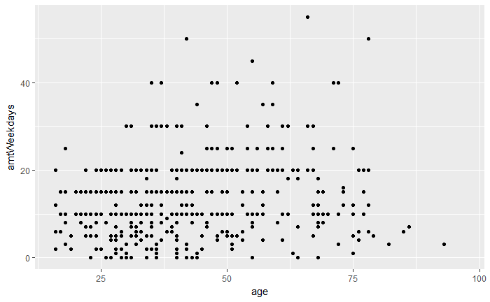

```r
# Smoking scatterplot
ggplot(data = smoking,
  aes(x = age, y = amtWeekdays)) +
  geom_point()
```

Transformations

Recall the bizarre pattern that you saw in the scatterplot between brain weight and body weight among mammals in a previous exercise. Can we use transformations to clarify this relationship?

ggplot2 provides several different mechanisms for viewing transformed relationships. The coord_trans() function transforms the coordinates of the plot. Alternatively, the scale_x_log10() and scale_y_log10() functions perform a base-10 log transformation of each axis. Note the differences in the appearance of the axes.

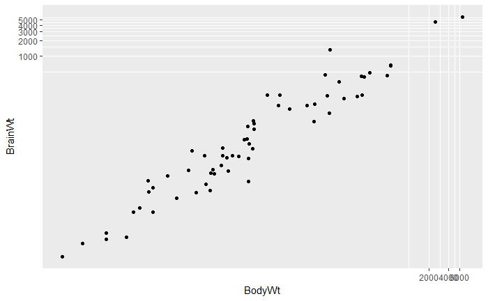

```r
# Scatterplot with coord_trans()
ggplot(data = mammals, aes(x = BodyWt, y = BrainWt)) +
  geom_point() +
  coord_trans(x = "log10", y = "log10")
```

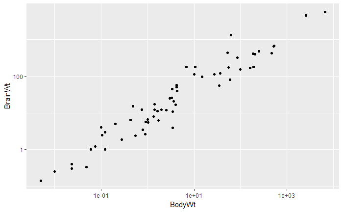

```r
# Scatterplot with scale_x_log10() and scale_y_log10()
ggplot(data = mammals, aes(x = BodyWt, y = BrainWt)) +
  geom_point() +
  scale_x_log10() + scale_y_log10()
```

Ouliers

Not a universal definition of outlier

```r
# Scatterplot of SLG vs. OBP
mlbBat10 %>%
  filter(AB >= 200) %>%
  ggplot(aes(x = OBP, y = SLG)) +
  geom_point()

# Identify the outlying player
mlbBat10 %>%
  filter(AB >= 200, OBP < 0.20)
```

[output not shown]

Correlation

Pearson product-moment correlation

```r
library(openintro)
```

```r
anscombe %>%
  group_by(set) %>%
  summarize(N = n(), mean(x), sd(x), mean(y), sd(y), cor(x, y))
```

```
Error in grouped_df_impl(data, unname(vars), drop) :
  Column `set` is unknown
```

Interpretation of Correlation

Spurious correlations

```r
# Create faceted scatterplot
ggplot(data = noise, aes(x = x, y = y)) +
  geom_point() +
  facet_wrap(~z) # i.e., "broken down by z"

# Compute correlations for each dataset
noise_summary <- noise %>%
  group_by(z) %>%
  summarize(N = n(), spurious_cor = cor(x, y))

# Isolate sets with correlations above 0.2 in absolute strength
noise_summary %>%
  filter(abs(spurious_cor) > 0.2)
```

[output not shown]

## 3. Visualization of linear models

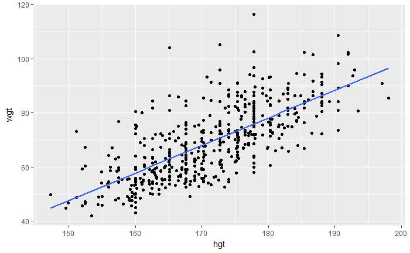

```r
# Scatterplot with regression line
ggplot(data = bdims, aes(x = hgt, y = wgt)) +
  geom_point() +
  geom_smooth(method = "lm", se = FALSE)
```

```r
NA
```

Understanding the linear model

Y = B0 + B1*X + u

prefers “noise” to “error” Gujarati: PRF: u is the stochastic (random) ERROR term SRF: e is the residual estimator of the noise/error term

### Fitting a linear model “by hand”

```r
# Print bdims_summary
bdims_summary

# Add slope and intercept
bdims_summary %>%
  mutate(slope = r*sd_wgt/sd_hgt,
         intercept = mean_wgt - slope * mean_hgt)
```

[output not shown]

Regression versus regression to the mean

## 4. Interpreting regression models

response ~ explanatory

interpreting slope coeffcient: units of respone variable per unit of explanatory variable

```r
# Linear model for weight as a function of height
lm(wgt ~ hgt, data = bdims)
```

```
Call:
lm(formula = wgt ~ hgt, data = bdims)

Coefficients:
(Intercept)          hgt
   -105.011        1.018
```

```r
# Linear model for SLG as a function of OBP
lm(SLG ~ OBP, data = mlbBat10)
```

```
Call:
lm(formula = SLG ~ OBP, data = mlbBat10)

Coefficients:
(Intercept)          OBP
   0.009407     1.110323
```

```r
# Log-linear model for body weight as a function of brain weight
lm(log(BodyWt) ~ log(BrainWt), data = mammals)
```

```
Call:
lm(formula = log(BodyWt) ~ log(BrainWt), data = mammals)

Coefficients:
 (Intercept)  log(BrainWt)
      -2.509         1.225
```

Your linear model object

- coef()
- summary()
- fitted.values() # same number of rows, but NAs dropped
- residuals()

broom is a package in the tidyverse.

```r
mod <- lm(wgt ~ hgt, data = bdims)
# Show the coefficients
coef(mod)
```

```
(Intercept)         hgt
-105.011254    1.017617
```

```r
# Show the full output
summary(mod)
```

```
Call:
lm(formula = wgt ~ hgt, data = bdims)

Residuals:
    Min      1Q  Median      3Q     Max
-18.743  -6.402  -1.231   5.059  41.103

Coefficients:
              Estimate Std. Error t value Pr(>|t|)
(Intercept) -105.01125    7.53941  -13.93   <2e-16 ***
hgt            1.01762    0.04399   23.14   <2e-16 ***
---
Signif. codes:  0 *** 0.001 ** 0.01 * 0.05 . 0.1   1

Residual standard error: 9.308 on 505 degrees of freedom
Multiple R-squared:  0.5145,    Adjusted R-squared:  0.5136
F-statistic: 535.2 on 1 and 505 DF,  p-value: < 2.2e-16
```

```r
# Mean of weights equal to mean of fitted values?
mean(bdims$wgt) == mean(fitted.values(mod))
```

```
[1] TRUE
```

```r
# Mean of the residuals
mean(residuals(mod))
```

```
[1] -1.266971e-15
```

```r
# Load broom
library(broom)
# Create bdims_tidy
bdims_tidy <- augment(mod)
# Glimpse the resulting data frame
glimpse(bdims_tidy)
```

```
Observations: 507
Variables: 9
$ wgt        <dbl> 65.6, 71.8, 80.7, 72.6, 78.8, 74.8, 86.4, 78.4, 62.0, 81.6, 76.6, 83.6, 90.0,...
$ hgt        <dbl> 174.0, 175.3, 193.5, 186.5, 187.2, 181.5, 184.0, 184.5, 175.0, 184.0, 180.0, ...
$ .fitted    <dbl> 72.05406, 73.37697, 91.89759, 84.77427, 85.48661, 79.68619, 82.23023, 82.7390...
$ .se.fit    <dbl> 0.4320546, 0.4520060, 1.0667332, 0.7919264, 0.8183471, 0.6151427, 0.7004864, ...
$ .resid     <dbl> -6.4540648, -1.5769666, -11.1975919, -12.1742745, -6.6866062, -4.8861906, 4.1...
$ .hat       <dbl> 0.002154570, 0.002358152, 0.013133942, 0.007238576, 0.007729629, 0.004367523,...
$ .sigma     <dbl> 9.312824, 9.317005, 9.303732, 9.301360, 9.312471, 9.314716, 9.315408, 9.31525...
$ .cooksd    <dbl> 5.201807e-04, 3.400330e-05, 9.758463e-03, 6.282074e-03, 2.025646e-03, 6.07059...
$ .std.resid <dbl> -0.69413418, -0.16961994, -1.21098084, -1.31269063, -0.72116141, -0.52609312,...
```

```r
augment(mod) %>%
  arrange(desc(.resid)) %>%
  head()
```

|  | wgt | hgt | .fitted | .se.fit | .resid | .hat | .sigma | .cooksd | .std.resid |
| --- | --- | --- | --- | --- | --- | --- | --- | --- | --- |
| 1 | 104.1 | 165.1 | 62.99728 | 0.4914889 | 41.10272 | 0.002788117 | 9.135102 | 0.027335737 | 4.421999 |
| 2 | 116.4 | 177.8 | 75.92101 | 0.5065670 | 40.47899 | 0.002961811 | 9.140611 | 0.028173878 | 4.355274 |
| 3 | 105.2 | 172.7 | 70.73116 | 0.4190138 | 34.46884 | 0.002026470 | 9.189635 | 0.013951116 | 3.706883 |
| 4 | 102.5 | 177.8 | 75.92101 | 0.5065670 | 26.57899 | 0.002961811 | 9.241520 | 0.012146866 | 2.859725 |
| 5 | 95.9 | 172.7 | 70.73116 | 0.4190138 | 25.16884 | 0.002026470 | 9.249437 | 0.007438442 | 2.706733 |
| 6 | 73.2 | 151.1 | 48.75064 | 0.9737632 | 24.44936 | 0.010944356 | 9.252694 | 0.038595550 | 2.641185 |

Making predictions The fitted.values() function or the augment()-ed data frame provides us with the fitted values for the observations that were in the original data. However, once we have fit the model, we may want to compute expected values for observations that were not present in the data on which the model was fit. These types of predictions are called out-of-sample.

The ben data frame contains a height and weight observation for one person. The mod object contains the fitted model for weight as a function of height for the observations in the bdims dataset. We can use the predict() function to generate expected values for the weight of new individuals. We must pass the data frame of new observations through the newdata argument.

```r
ben <- data.frame(74.8, 182.8)
colnames(ben) <- c("wgt", "hgt")
# Print ben
ben
```

| wgt | hgt |
| --- | --- |
| 74.8 | 182.8 |

```r
# Predict the weight of ben
predict(mod, ben)
```

```
       1
81.00909
```

```r
library(ggplot2)
# Add the line to the scatterplot
ggplot(data = bdims, aes(x = hgt, y = wgt)) +
  geom_point() +
  geom_abline(data = coefs,
              aes(intercept = `(Intercept)`, slope = hgt),
              color = "dodgerblue")
```

```
Error in fortify(data) : object 'coefs' not found
```

## 5. Model fit

Standard error of residuals One way to assess strength of fit is to consider how far off the model is for a typical case. That is, for some observations, the fitted value will be very close to the actual value, while for others it will not. The magnitude of a typical residual can give us a sense of generally how close our estimates are.

```r
# View summary of model
summary(mod)
```

```
Call:
lm(formula = wgt ~ hgt, data = bdims)

Residuals:
    Min      1Q  Median      3Q     Max
-18.743  -6.402  -1.231   5.059  41.103

Coefficients:
              Estimate Std. Error t value Pr(>|t|)
(Intercept) -105.01125    7.53941  -13.93   <2e-16 ***
hgt            1.01762    0.04399   23.14   <2e-16 ***
---
Signif. codes:  0 *** 0.001 ** 0.01 * 0.05 . 0.1   1

Residual standard error: 9.308 on 505 degrees of freedom
Multiple R-squared:  0.5145,    Adjusted R-squared:  0.5136
F-statistic: 535.2 on 1 and 505 DF,  p-value: < 2.2e-16
```

```r
# Compute the mean of the residuals
mean(residuals(mod))
```

```
[1] -1.266971e-15
```

```r
# Compute RMSE
sqrt(sum(residuals(mod)^2) / df.residual(mod))
```

```
[1] 9.30804
```

Comparing model fits

```r
# View model summary
summary(mod)

# Compute R-squared
bdims_tidy %>%
  summarize(var_y = var(wgt), var_e = var(.resid)) %>%
  mutate(R_squared = 1 - var_e/var_y)
```

[output not shown]

```r
# Compute SSE for null model
mod_null %>%
  summarize(SSE = var(.resid))
```

```
Error in eval(lhs, parent, parent) : object 'mod_null' not found
```

Unusual points

Leverage and Influence

High leverage plus large residual = high influence

Leverage The leverage of an observation in a regression model is defined entirely in terms of the distance of that observation from the mean of the explanatory variable. That is, observations close to the mean of the explanatory variable have low leverage, while observations far from the mean of the explanatory variable have high leverage. Points of high leverage may or may not be influential.

The augment() function from the broom package will add the leverage scores (.hat) to a model data frame.

```r
# Rank points of high leverage
mod %>%
  augment() %>%
  arrange(desc(.hat)) %>%
  head()
```

|  | wgt | hgt | .fitted | .se.fit | .resid | .hat | .sigma | .cooksd | .std.resid |
| --- | --- | --- | --- | --- | --- | --- | --- | --- | --- |
| 1 | 85.5 | 198.1 | 96.57863 | 1.255712 | -11.078629 | 0.01819968 | 9.303950 | 0.0133734319 | -1.2012024 |
| 2 | 90.9 | 197.1 | 95.56101 | 1.214264 | -4.661012 | 0.01701803 | 9.314916 | 0.0022081690 | -0.5050673 |
| 3 | 49.8 | 147.2 | 44.78194 | 1.131432 | 5.018065 | 0.01477545 | 9.314548 | 0.0022120570 | 0.5431383 |
| 4 | 80.7 | 193.5 | 91.89759 | 1.066733 | -11.197592 | 0.01313394 | 9.303732 | 0.0097584634 | -1.2109808 |
| 5 | 95.9 | 193.0 | 91.38878 | 1.046493 | 4.511216 | 0.01264027 | 9.315075 | 0.0015228117 | 0.4877505 |
| 6 | 44.8 | 149.5 | 47.12245 | 1.037916 | -2.322454 | 0.01243391 | 9.316688 | 0.0003968468 | -0.2510763 |

Dealing with unusual points

```r
# Create nontrivial_players
nontrivial_players <- mlbBat10 %>%
  filter(AB >= 10 & OBP < 0.50)
# Fit model to new data
mod_cleaner <- lm(SLG ~ OBP, data = nontrivial_players)
# View model summary
summary(mod_cleaner)
```

```
Call:
lm(formula = SLG ~ OBP, data = nontrivial_players)

Residuals:
     Min       1Q   Median       3Q      Max
-0.31383 -0.04165 -0.00261  0.03992  0.35819

Coefficients:
             Estimate Std. Error t value Pr(>|t|)
(Intercept) -0.043326   0.009823  -4.411 1.18e-05 ***
OBP          1.345816   0.033012  40.768  < 2e-16 ***
---
Signif. codes:  0 *** 0.001 ** 0.01 * 0.05 . 0.1   1

Residual standard error: 0.07011 on 734 degrees of freedom
Multiple R-squared:  0.6937,    Adjusted R-squared:  0.6932
F-statistic:  1662 on 1 and 734 DF,  p-value: < 2.2e-16
```

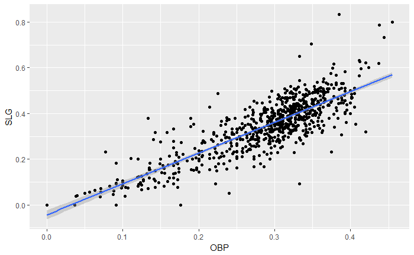

```r
# Visualize new model
ggplot(data = nontrivial_players, aes(x = OBP, y = SLG)) +
  geom_point() +
  geom_smooth(method = "lm")
```